# Module 8: Interpretation and Labeling

LCA for Social Science Research

2026-04-06

# 1 Purpose of This Module

The LCA model identifies unobserved subgroups and assigns probabilistic memberships, but it does not tell you what the subgroups mean. The model outputs numbers — item-response probabilities, class prevalences — and it is your responsibility as the researcher to translate those numbers into substantive meaning. This translation involves two distinct tasks: interpreting the class profiles by identifying the patterns in the item-response probabilities, and labeling the classes by assigning descriptive names that accurately convey those patterns. Both tasks carry methodological risks. This module provides the procedures for executing them rigorously.

> **Prerequisites:** This module loads objects from Modules 4 and 6. Render those modules first.

```r
load("lca_prepared_data.RData")
load("lca_selected_model.RData")
load("lca_diagnostics.RData")
library(poLCA)
library(tidyverse)
library(knitr)
library(kableExtra)
library(reshape2)
```

# 2 Extracting Item-Response Probabilities

## 2.1 How poLCA Stores Probabilities

`poLCA` stores item-response probabilities in the `$probs` element of the model output. This is a named list — one element per indicator variable. Each element is a matrix with rows corresponding to classes and columns corresponding to response categories.

For a binary item, the matrix has 2 columns: column 1 = $P(\text{response} = 1 \mid \text{class})$, column 2 = $P(\text{response} = 2 \mid \text{class})$. These always sum to 1 within each row.

```r
# Extract P(Agree) for each item and class
prob_table <- matrix(NA, nrow = length(best_model$P), ncol = length(item_names))
for (j in seq_along(item_names)) {
  prob_table[, j] <- best_model$probs[[item_names[j]]][, 1]
}
colnames(prob_table) <- item_names
rownames(prob_table) <- paste("Class", 1:length(best_model$P))

kable(round(prob_table, 3),
      caption = "Item-Response Probabilities: P(Agree) by Latent Class") %>%
  kable_styling(full_width = FALSE)
```

Item-Response Probabilities: P(Agree) by Latent Class

|  | REDIST | IMMIG | PRIDE | TRUST | TRAD | ENVIR |
| --- | --- | --- | --- | --- | --- | --- |
| Class 1 | 0.226 | 0.242 | 0.292 | 0.537 | 0.026 | 0.277 |
| Class 2 | 0.179 | 0.835 | 0.901 | 0.198 | 0.913 | 0.196 |
| Class 3 | 0.997 | 0.157 | 0.231 | 0.589 | 0.181 | 0.937 |
| Class 4 | 1.000 | 0.870 | 0.873 | 0.155 | 0.779 | 0.812 |

# 3 Reading the Profiles

## 3.1 The Interpretation Process

Interpretation proceeds by examining each class (row) and asking: which items does this class endorse at high rates? Which does it reject? What pattern emerges when you consider all items together?

For each class:

1. **Identify high-probability items** (above 0.70). These are attitudes or behaviors that most class members endorse.
2. **Identify low-probability items** (below 0.30). These are attitudes or behaviors that most class members reject.
3. **Identify ambiguous items** (0.30–0.70). These items do not strongly characterize the class.
4. **Consider the pattern across all items.** Does it correspond to a recognizable theoretical type? Does it suggest a coherent attitudinal configuration?

## 3.2 Detailed Profile Analysis

```r
cat("=== DETAILED PROFILE ANALYSIS ===\n\n")
```

```
## === DETAILED PROFILE ANALYSIS ===
```

```r
for (c in 1:length(best_model$P)) {
  cat(sprintf("--- Class %d (%.1f%% of sample, n ≈ %d) ---\n",
              c, best_model$P[c] * 100, round(best_model$P[c] * nrow(sim_data))))

  probs_c <- prob_table[c, ]

  high <- names(probs_c[probs_c >= 0.70])
  low <- names(probs_c[probs_c <= 0.30])
  ambig <- names(probs_c[probs_c > 0.30 & probs_c < 0.70])

  if (length(high) > 0) cat("  HIGH endorsement (>0.70):", paste(high, collapse = ", "), "\n")
  if (length(low) > 0)  cat("  LOW endorsement (<0.30): ", paste(low, collapse = ", "), "\n")
  if (length(ambig) > 0) cat("  AMBIGUOUS (0.30-0.70):   ", paste(ambig, collapse = ", "), "\n")
  cat("\n")
}
```

```
## --- Class 1 (27.2% of sample, n ≈ 217) ---
##   LOW endorsement (<0.30):  REDIST, IMMIG, PRIDE, TRAD, ENVIR
##   AMBIGUOUS (0.30-0.70):    TRUST
##
## --- Class 2 (30.0% of sample, n ≈ 240) ---
##   HIGH endorsement (>0.70): IMMIG, PRIDE, TRAD
##   LOW endorsement (<0.30):  REDIST, TRUST, ENVIR
##
## --- Class 3 (23.5% of sample, n ≈ 188) ---
##   HIGH endorsement (>0.70): REDIST, ENVIR
##   LOW endorsement (<0.30):  IMMIG, PRIDE, TRAD
##   AMBIGUOUS (0.30-0.70):    TRUST
##
## --- Class 4 (19.3% of sample, n ≈ 154) ---
##   HIGH endorsement (>0.70): REDIST, IMMIG, PRIDE, TRAD, ENVIR
##   LOW endorsement (<0.30):  TRUST
```

# 4 Visualizing the Profiles

## 4.1 Profile Plot (Line Plot)

The profile plot is the standard visualization for LCA results. It plots $P(\text{Agree})$ for each item across all classes, making the qualitative and quantitative differences immediately visible.

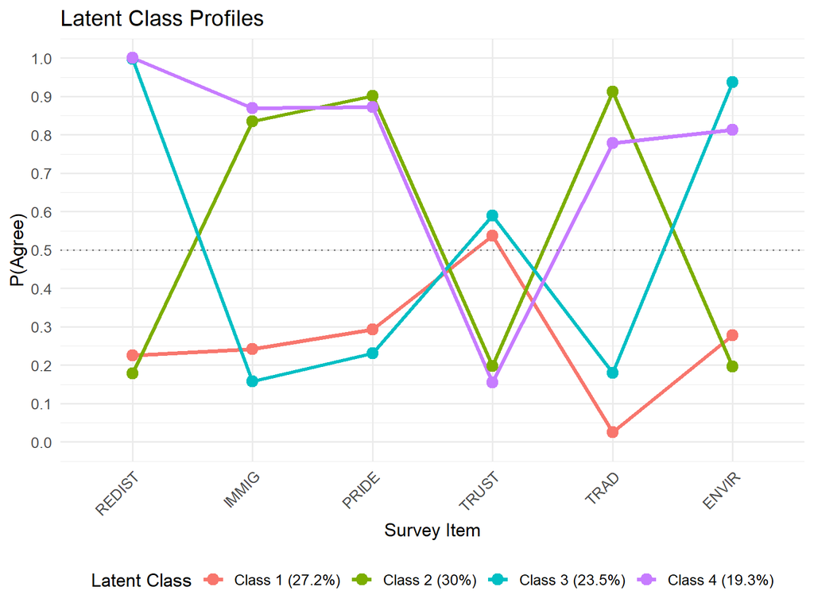

```r
prob_df <- as.data.frame(prob_table)
prob_df$Class <- factor(paste("Class", 1:nrow(prob_df)))
prob_df$Prevalence <- paste0(round(best_model$P * 100, 1), "%")
prob_df$Label <- paste0(prob_df$Class, " (", prob_df$Prevalence, ")")

prob_long <- prob_df %>%
  select(-Prevalence) %>%
  pivot_longer(cols = all_of(item_names), names_to = "Item", values_to = "Probability") %>%
  mutate(Item = factor(Item, levels = item_names))

ggplot(prob_long, aes(x = Item, y = Probability, color = Label, group = Label)) +
  geom_line(linewidth = 1.3) +
  geom_point(size = 3.5) +
  scale_y_continuous(limits = c(0, 1), breaks = seq(0, 1, 0.1)) +
  geom_hline(yintercept = 0.5, linetype = "dotted", color = "grey50") +
  labs(title = "Latent Class Profiles",
       x = "Survey Item", y = "P(Agree)",
       color = "Latent Class") +
  theme_minimal(base_size = 13) +
  theme(axis.text.x = element_text(angle = 45, hjust = 1),
        legend.position = "bottom")
```

## 4.2 Grouped Bar Plot

An alternative visualization that makes within-item class comparisons easier to read:

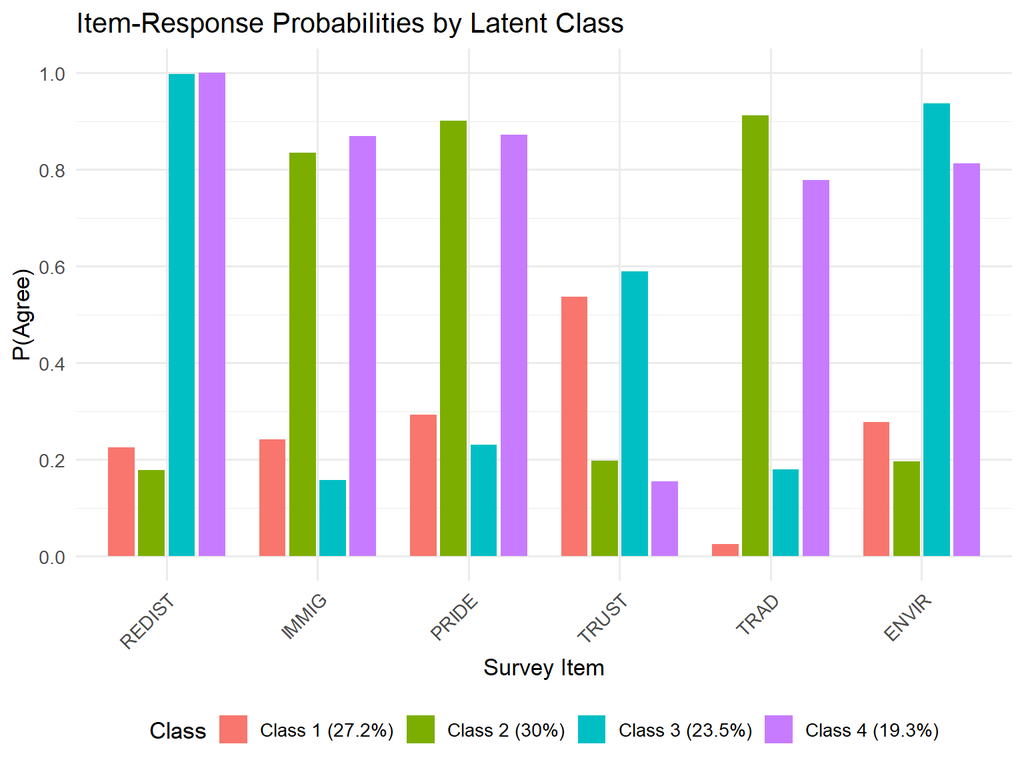

```r
ggplot(prob_long, aes(x = Item, y = Probability, fill = Label)) +
  geom_bar(stat = "identity", position = position_dodge(width = 0.8), width = 0.7) +
  scale_y_continuous(limits = c(0, 1), breaks = seq(0, 1, 0.2)) +
  labs(title = "Item-Response Probabilities by Latent Class",
       x = "Survey Item", y = "P(Agree)", fill = "Class") +
  theme_minimal(base_size = 13) +
  theme(axis.text.x = element_text(angle = 45, hjust = 1),
        legend.position = "bottom")
```

## 4.3 Heatmap

A heatmap provides a compact visualization when you have many items:

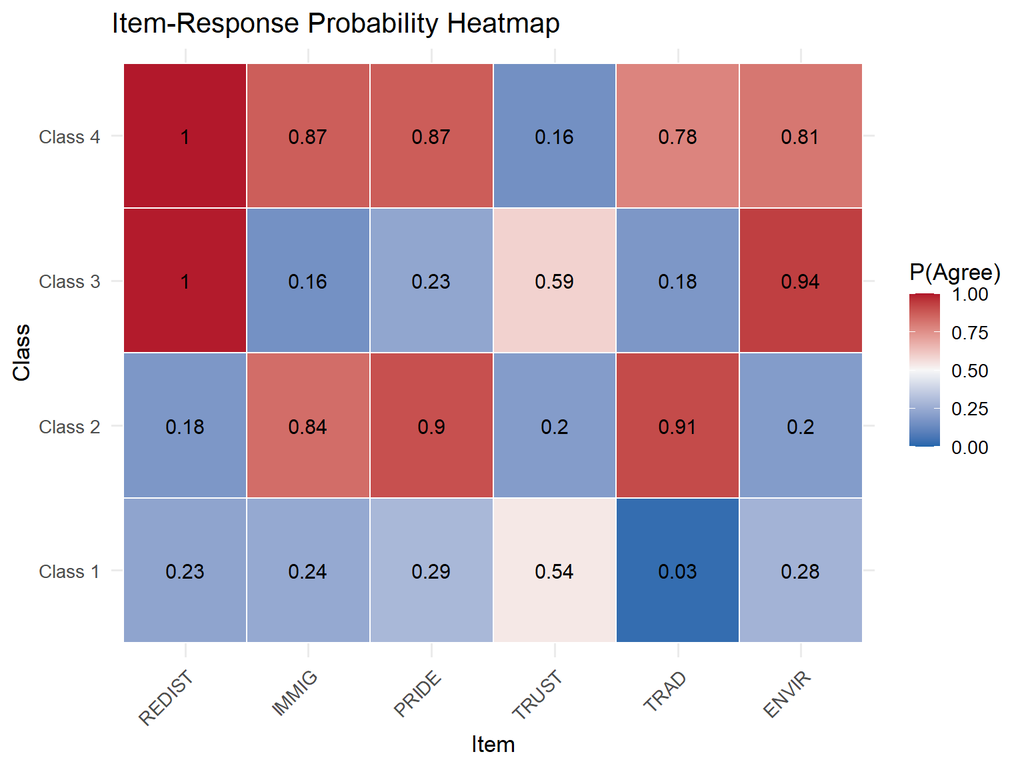

```r
prob_heat <- melt(prob_table)
names(prob_heat) <- c("Class", "Item", "Probability")

ggplot(prob_heat, aes(x = Item, y = Class, fill = Probability)) +
  geom_tile(color = "white", linewidth = 0.5) +
  geom_text(aes(label = round(Probability, 2)), color = "black", size = 4) +
  scale_fill_gradient2(low = "#2166AC", mid = "#F7F7F7", high = "#B2182B",
                       midpoint = 0.5, limits = c(0, 1)) +
  labs(title = "Item-Response Probability Heatmap",
       x = "Item", y = "Class", fill = "P(Agree)") +
  theme_minimal(base_size = 13) +
  theme(axis.text.x = element_text(angle = 45, hjust = 1))
```

# 5 Quantitative vs. Qualitative Differences

## 5.1 Quantitative Differences

If the classes can be logically ordered along a single continuum — for example, one class has uniformly low endorsement, another has moderate endorsement, and a third has uniformly high endorsement across all items — the differences are quantitative. The classes differ in degree, not kind. They represent different levels of the same underlying disposition.

Quantitative differences are common when the latent construct is essentially unidimensional. In this case, LCA is recovering a dimensional structure (like a factor) but discretizing it into categories. This is not inherently problematic — it may be useful for applied purposes (e.g., distinguishing “low risk,” “moderate risk,” and “high risk” groups) — but it should be acknowledged that the latent structure is dimensional rather than truly typological.

## 5.2 Qualitative Differences

If the classes exhibit cross-cutting profiles — one class is high on some items and low on others, while another class shows the reverse pattern — the differences are qualitative. The classes represent genuinely distinct types that cannot be ordered on a single scale.

Qualitative differences are the more theoretically interesting finding in most social science applications. They indicate that the population contains subgroups whose attitudinal or behavioral configurations are fundamentally different in kind, not just in degree. A class that endorses redistribution AND immigration restriction cannot be placed on a single left-right continuum — it represents a qualitatively distinct type.

In practice, many LCA solutions exhibit a mix of both: some class pairs differ quantitatively (one is a more extreme version of the other) while others differ qualitatively (their profiles cross over).

```r
cat("=== QUANTITATIVE vs. QUALITATIVE ASSESSMENT ===\n\n")
```

```
## === QUANTITATIVE vs. QUALITATIVE ASSESSMENT ===
```

```r
cat("Check: Can the classes be ordered from 'low overall' to 'high overall'?\n")
```

```
## Check: Can the classes be ordered from 'low overall' to 'high overall'?
```

```r
cat("If yes → quantitative differences (dimensional).\n")
```

```
## If yes → quantitative differences (dimensional).
```

```r
cat("If profiles cross over → qualitative differences (typological).\n\n")
```

```
## If profiles cross over → qualitative differences (typological).
```

```r
# Compute mean endorsement rate per class as a rough check
mean_endorse <- rowMeans(prob_table)
cat("Mean P(Agree) across all items by class:\n")
```

```
## Mean P(Agree) across all items by class:
```

```r
for (c in 1:length(best_model$P)) {
  cat(sprintf("  Class %d: %.3f\n", c, mean_endorse[c]))
}
```

```
##   Class 1: 0.267
##   Class 2: 0.537
##   Class 3: 0.515
##   Class 4: 0.748
```

```r
cat("\nIf these means vary but the item-level patterns do NOT cross,\n")
```

```
##
## If these means vary but the item-level patterns do NOT cross,
```

```r
cat("the structure is primarily quantitative.\n")
```

```
## the structure is primarily quantitative.
```

```r
cat("If the profiles cross (visible in the profile plot), the structure\n")
```

```
## If the profiles cross (visible in the profile plot), the structure
```

```r
cat("contains qualitative differences.\n")
```

```
## contains qualitative differences.
```

# 6 The Naming Fallacy

## 6.1 What It Is

The naming fallacy occurs when a researcher assigns a label to a latent class that oversimplifies, misrepresents, or imposes a theoretical interpretation not warranted by the actual pattern of item-response probabilities. The label becomes a stand-in for the class, and readers interpret it as if it describes the class accurately — but it does not.

## 6.2 Why It Is Dangerous

Once a class is labeled, the label shapes all subsequent interpretation. If you label a class “authoritarian” because it has high endorsement of traditional values, readers will expect that class to exhibit authoritarian characteristics across the board. If the class also has high endorsement of redistribution and environmental regulation — features not typically associated with authoritarianism — the label is misleading. The class may be better described as “communitarian” or “socially conservative but economically progressive.”

The naming fallacy is especially pernicious because latent classes are complex, multivariate entities. They are defined by the full pattern of item-response probabilities across all indicators. A label, by its nature, is a one- or two-word summary. Reducing a multidimensional pattern to a single label necessarily discards information, and the information that is discarded matters.

## 6.3 How to Avoid It

1. **Start with descriptive labels.** In early stages of analysis, use neutral, profile-based labels: “High-economic, low-cultural class” or “Class A: high REDIST, high ENVIR, low IMMIG.” These labels directly reference the data and make no theoretical claims.
2. **Apply theoretical labels only after validation.** Reserve theoretically loaded labels (e.g., “progressive,” “communitarian”) for the final interpretation, after you have confirmed that the class relates to external variables in theoretically expected ways (Module 9).
3. **Check every label against every item.** When you assign a label, verify that the label is consistent with the class’s probability on every indicator, not just the most salient ones. A label that accurately describes the pattern on 4 of 6 items but contradicts the other 2 is misleading.
4. **Acknowledge ambiguity.** If a class has a mixed or ambiguous profile that does not correspond to any established theoretical type, say so. “Mixed profile with elements of both conservative and progressive attitudes” is more honest than forcing the class into a predefined category.
5. **Solicit input from domain experts.** If possible, have colleagues with substantive expertise in the domain review the profiles and proposed labels independently. This provides a check against confirmation bias.

# 7 Worked Example: Labeling the Classes

```r
cat("=== PROPOSED LABELS ===\n\n")
```

```
## === PROPOSED LABELS ===
```

```r
for (c in 1:length(best_model$P)) {
  cat(sprintf("Class %d (%.1f%%)\n", c, best_model$P[c] * 100))
  cat("  Profile: ")

  probs_c <- prob_table[c, ]
  for (j in seq_along(item_names)) {
    direction <- ifelse(probs_c[j] > 0.60, "HIGH",
                  ifelse(probs_c[j] < 0.40, "low", "mid"))
    cat(sprintf("%s=%s ", item_names[j], direction))
  }
  cat("\n\n")
}
```

```
## Class 1 (27.2%)
##   Profile: REDIST=low IMMIG=low PRIDE=low TRUST=mid TRAD=low ENVIR=low
##
## Class 2 (30.0%)
##   Profile: REDIST=low IMMIG=HIGH PRIDE=HIGH TRUST=low TRAD=HIGH ENVIR=low
##
## Class 3 (23.5%)
##   Profile: REDIST=HIGH IMMIG=low PRIDE=low TRUST=mid TRAD=low ENVIR=HIGH
##
## Class 4 (19.3%)
##   Profile: REDIST=HIGH IMMIG=HIGH PRIDE=HIGH TRUST=low TRAD=HIGH ENVIR=HIGH
```

```r
cat("Note: Final labels should be assigned only after construct validation\n")
```

```
## Note: Final labels should be assigned only after construct validation
```

```r
cat("(Module 9) confirms that the classes relate to external variables\n")
```

```
## (Module 9) confirms that the classes relate to external variables
```

```r
cat("in theoretically expected ways.\n")
```

```
## in theoretically expected ways.
```

```r
# Save the probability table and class information for subsequent modules
interpretation <- list(
  prob_table = prob_table,
  class_prevalences = best_model$P,
  n_classes = length(best_model$P)
)
save(interpretation, file = "lca_interpretation.RData")
```

# 8 Writing the Interpretation: A Model Paragraph

# 9 Summary

After this module, you should be able to:

1. Extract and display item-response probabilities from `poLCA` output.
2. Systematically read class profiles by identifying high, low, and ambiguous items.
3. Produce profile plots, bar charts, and heatmaps.
4. Distinguish quantitative from qualitative differences between classes.
5. Explain the naming fallacy and apply strategies to avoid it.
6. Assign provisional descriptive labels and defer theoretical labels until after validation.

Proceed to **Module 9: Validation** to establish that your classes are genuine population features rather than statistical artifacts.

# 10 References

Collins, L. M., & Lanza, S. T. (2010). *Latent class and latent transition analysis.* Wiley.

Weller, B. E., Bowen, N. K., & Faubert, S. J. (2020). Latent class analysis: A guide to best practice. *Journal of Black Psychology, 46*(4), 287–311.

Bonikowski, B. (2021). Mapping culture with latent class analysis. *Nations and Nationalism, 27*(4), 926–941.

↩︎ Course Index